# Proyecto RNA-Seq

Paulina Rosales B

26 de febrero, 2021

# Generealidades

Este proyecto busca retomar las herramientas y conocimientos recuperados en el [curso de RNA-seq 2021](https://github.com/lcolladotor/rnaseq_LCG-UNAM_2021) impartido por [Leonardo Collado-Torres](http://lcolladotor.github.io/) para los estudiantes de la [Licenciatura en Ciencias Genómicas](https://lcg.unam.mx/).

## Proyecto: Datos de SRP11148

El proyecto que elegí fue: [*“Transcriptomic and genomic profiling of early-stage ovarian carcinomas associated with histotype and overall survival [RNA-Seq]”*](https://www.ncbi.nlm.nih.gov/pmc/articles/PMC6205557/) (ID: SRP11148), la elección fue basada únicamente en interés por el tema y número de muestras (n=96).

### *Abstract*

*“Ovarian cancer is the most lethal gynecological malignancy in the western world. Despite recent efforts to characterize ovarian cancer using molecular profiling, few targeted treatment options are currently available. Here, we examined genetic variants, fusion transcripts, SNP genotyping, and gene expression patterns for early-stage (I, II) ovarian carcinomas (n=96) in relation to clinicopathological characteristics and clinical outcome, thereby identifying novel genetic features of ovarian carcinomas. Furthermore, mutation frequencies of specific genetic variants and/or their gene expression patterns were associated with histotype and overall survival, e.g. SLC28A2 (mucinous ovarian carcinoma histotype), ARCN1 (low expression in 0-2 year survival group), and tumor suppressor MTUS1 (mutation status and overall survival). The long non-coding RNA MALAT1 was identified as a highly promiscuous fusion transcript in ovarian carcinoma. Moreover, gene expression deregulation for 23 genes was associated with tumor aggressiveness. Taken together, the novel biomarkers identified here may improve ovarian carcinoma subclassification and patient stratification according to histotype and overall survival. Overall design: Whole-transcriptome RNA sequencing (RNA-seq) was performed for 96 early-stage primary invasive ovarian carcinomas.”*

# Librerías utilizadas

```r
library("recount3")
library("ggplot2")
library("edgeR")
library("limma")
library("RColorBrewer")
library("pheatmap")
```

# Importación de datos

Los datos de RNA-seq son descargados a través del paquete [*recount3*](http://bioconductor.org/packages/release/bioc/html/recount3.html) de [*Bioconductor*](http://bioconductor.org/).

```r
## library("recount3")
human_projects <- available_projects()

rse_gene_SRP111481 <- create_rse(
    subset(
        human_projects,
        project == "SRP111481" & project_type == "data_sources"
    )
)
```

```r
## Convertir las cuentas por nucleotido a cuentas por lectura
assay(rse_gene_SRP111481, "counts") <- compute_read_counts(rse_gene_SRP111481)
```

# Limpieza y formateo de datos

Para evitar problemas de interpretación durante el manejo de datos, es necesario verificar que la información de cada categoría permita su uso; y en caso de ser necesario, curarla.

Con los siguientes *outputs* nos damos cuenta que el proyecto cuenta con 4 atributos:

- `age`
- `figo stage`
- `source_name`
- `tissue`

```r
head(rse_gene_SRP111481$sra.sample_attributes)
```

```
## [1] "age;;39|figo stage;;II|source_name;;Primary invasive ovarian carcinomas|tissue;;early-stage primary invasive ovarian carcinoma"
## [2] "age;;58|figo stage;;I|source_name;;Primary invasive ovarian carcinomas|tissue;;early-stage primary invasive ovarian carcinoma"
## [3] "age;;64|figo stage;;I|source_name;;Primary invasive ovarian carcinomas|tissue;;early-stage primary invasive ovarian carcinoma"
## [4] "age;;67|figo stage;;I|source_name;;Primary invasive ovarian carcinomas|tissue;;early-stage primary invasive ovarian carcinoma"
## [5] "age;;61|figo stage;;II|source_name;;Primary invasive ovarian carcinomas|tissue;;early-stage primary invasive ovarian carcinoma"
## [6] "age;;64|figo stage;;II|source_name;;Primary invasive ovarian carcinomas|tissue;;early-stage primary invasive ovarian carcinoma"
```

Probablemete el espacio en el atributo `figo stage` haga ruido, por lo tanto la modifiqué a `figo_stage`:

```r
rse_gene_SRP111481$sra.sample_attributes <- gsub("figo stage", "figo_stage", rse_gene_SRP111481$sra.sample_attributes)
rse_gene_SRP111481$sra.sample_attributes[1:3]
```

```
## [1] "age;;39|figo_stage;;II|source_name;;Primary invasive ovarian carcinomas|tissue;;early-stage primary invasive ovarian carcinoma"
## [2] "age;;58|figo_stage;;I|source_name;;Primary invasive ovarian carcinomas|tissue;;early-stage primary invasive ovarian carcinoma"
## [3] "age;;64|figo_stage;;I|source_name;;Primary invasive ovarian carcinomas|tissue;;early-stage primary invasive ovarian carcinoma"
```

Además separaremos los atributos y los agregaremos al objeto para poder manejarlos.

```r
## Separar los atributos e incluirlos al data.frame
rse_gene_SRP111481 <- expand_sra_attributes(rse_gene_SRP111481)
colData(rse_gene_SRP111481)[
    ,
    grepl("^sra_attribute", colnames(colData(rse_gene_SRP111481)))
]
```

```
## DataFrame with 96 rows and 4 columns
##            sra_attribute.age sra_attribute.figo_stage sra_attribute.source_name
##                  <character>              <character>               <character>
## SRR5815895                39                       II    Primary invasive ova..
## SRR5815896                58                        I    Primary invasive ova..
## SRR5815897                64                        I    Primary invasive ova..
## SRR5815898                67                        I    Primary invasive ova..
## SRR5815899                61                       II    Primary invasive ova..
## ...                      ...                      ...                       ...
## SRR5815937                55                        I    Primary invasive ova..
## SRR5815939                49                        I    Primary invasive ova..
## SRR5815940                75                        I    Primary invasive ova..
## SRR5815947                80                        I    Primary invasive ova..
## SRR5815948                25                        I    Primary invasive ova..
##              sra_attribute.tissue
##                       <character>
## SRR5815895 early-stage primary ..
## SRR5815896 early-stage primary ..
## SRR5815897 early-stage primary ..
## SRR5815898 early-stage primary ..
## SRR5815899 early-stage primary ..
## ...                           ...
## SRR5815937 early-stage primary ..
## SRR5815939 early-stage primary ..
## SRR5815940 early-stage primary ..
## SRR5815947 early-stage primary ..
## SRR5815948 early-stage primary ..
```

## Formateo

Modificar los datos tipo caracter que requieran cambio.

```r
## Comprobar que la variable categorica figo_stage se pueda convertir a dummy variable
table(rse_gene_SRP111481$sra_attribute.figo_stage)
```

```
##
##  I II
## 64 32
```

Formatear el tipo de dato para que sean manipulables.

```r
## Pasar de character a nuemric o factor
rse_gene_SRP111481$sra_attribute.age <- as.numeric(rse_gene_SRP111481$sra_attribute.age)
rse_gene_SRP111481$sra_attribute.figo_stage <- factor(rse_gene_SRP111481$sra_attribute.figo_stage)

## Resumen de las variables de interés
summary(as.data.frame(colData(rse_gene_SRP111481)[
    ,
    grepl("^sra_attribute.[age|figo_stage|source_name|tissue]", colnames(colData(rse_gene_SRP111481)))
]))
```

```
##  sra_attribute.age sra_attribute.figo_stage sra_attribute.source_name
##  Min.   :25.00     I :64                    Length:96
##  1st Qu.:52.00     II:32                    Class :character
##  Median :63.00                              Mode  :character
##  Mean   :63.15
##  3rd Qu.:74.25
##  Max.   :86.00
##  sra_attribute.tissue
##  Length:96
##  Class :character
##  Mode  :character
##
##
##
```

# Transformación de datos

Una vez que los datos son legibles y manejables, podemos manipularlos de acuerdo al objetivo.

## Crear una nueva variable categórica

Crear la categoría `adult` para dividir en dos rangos de edad:

- `young` - menor a 60 años
- `old` - mayor o igual a 60 años

```r
rse_gene_SRP111481$adult <- factor(ifelse(rse_gene_SRP111481$sra_attribute.age < 60, "young", "old"))
table(rse_gene_SRP111481$adult)
```

```
##
##   old young
##    60    36
```

## Filtrado

Muchos de los datos pueden contener información desviada que haga ruido en nuestro análisis, por lo tanto es necesario eliminarla. Para la filtración utilizaremos dos parámetros:

- **Por calidad de la librería:** de acuerdo a la proporción de lecturas asignadas a genes/lecturas totales.
- **Por niveles de expresión:** de acuerdo a niveles promedio de expresión de los datos y valores como el *cpm (counts per million)*.

### Calidad de la librería

Calculamos la proporción de genes asignados, donde valores cercanos a 1 indican mayor asignación de lecturas a genes. Dando a entender que la calidad de la librería es buena.

```r
## Calcular la proporcion de genes para saber la calidad
rse_gene_SRP111481$assigned_gene_prop <- rse_gene_SRP111481$recount_qc.gene_fc_count_all.assigned / rse_gene_SRP111481$recount_qc.gene_fc_count_all.total
summary(rse_gene_SRP111481$assigned_gene_prop)
```

```
##    Min. 1st Qu.  Median    Mean 3rd Qu.    Max.
##  0.1511  0.3725  0.4240  0.4166  0.4616  0.6476
```

Podemos ver que tenemos **proporciones desde 0.1511 hasta 0.6476.**

```r
## Salvar el objeto entero en caso de necesitar regresar a la version original
rse_gene_SRP111481_unfiltered <- rse_gene_SRP111481
```

```r
## Comparar proporciones de cada grupo
## Por rango de edad
with(colData(rse_gene_SRP111481), tapply(assigned_gene_prop, adult, summary))
```

```
## $old
##    Min. 1st Qu.  Median    Mean 3rd Qu.    Max.
##  0.2036  0.3725  0.4231  0.4153  0.4661  0.5604
##
## $young
##    Min. 1st Qu.  Median    Mean 3rd Qu.    Max.
##  0.1511  0.3764  0.4240  0.4186  0.4559  0.6476
```

```r
## Por etapa FIGO
with(colData(rse_gene_SRP111481), tapply(assigned_gene_prop, sra_attribute.figo_stage, summary))
```

```
## $I
##    Min. 1st Qu.  Median    Mean 3rd Qu.    Max.
##  0.2290  0.3708  0.4131  0.4164  0.4552  0.6476
##
## $II
##    Min. 1st Qu.  Median    Mean 3rd Qu.    Max.
##  0.1511  0.3795  0.4423  0.4169  0.4666  0.5604
```

Visualizando todas las proporciones nos damos cuenta de que la frecuencia de las proporciones menores son pocas, por lo tanto podemos eliminarlas.

Al ser un análisis de calidad, evité eliminar datos cercanos a uno aunque se alejaran de la distrbución.

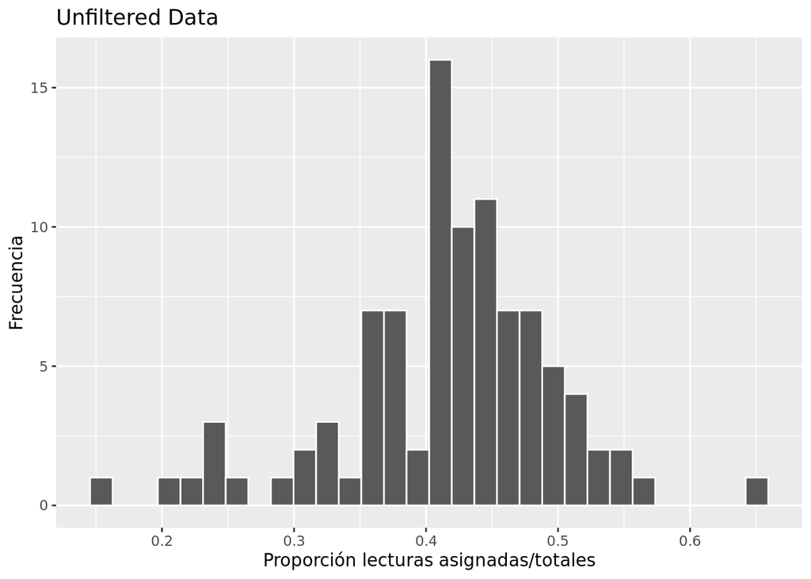

```r
## library("ggplot2")
plot_df <- as.data.frame(colData(rse_gene_SRP111481)[, "assigned_gene_prop"])
colnames(plot_df) <- "Calidad"

qplot(plot_df$Calidad, geom = "histogram", col = I("white"), xlab = "Proporción lecturas asignadas/totales", ylab = "Frecuencia", main = "Unfiltered Data")
```

Verificar cuántas variables se pierden.

```r
## Estimación de punto de corte
table(rse_gene_SRP111481$assigned_gene_prop < 0.3)
```

```
##
## FALSE  TRUE
##    88     8
```

```r
## Eliminar aquellas muestras con proporciones bajas
rse_gene_SRP111481 <- rse_gene_SRP111481[, rse_gene_SRP111481$assigned_gene_prop > 0.3]
```

### Niveles de expresión

Necesitamos crear un objeto `DGEList` *(Differential Gene Expression List)* a partir de las lecturas. Con él podremos manipular e interpretar los niveles de expresión, y así, podemos eliminar datos ruidosos.

Es necesario que la **normalizacion de datos** se lleve a acabo desde este punto para evitar que las diferencias por normalización sean filtradas.

```r
## library("edgeR")
dge <- DGEList(
    counts = assay(rse_gene_SRP111481, "counts"),
    genes = rowData(rse_gene_SRP111481)
)
## Calcular factores para normalización
dge_unnorm <- dge
dge <- calcNormFactors(dge)
```

Utilizamos valores como el *cpm* para la filtración posterior.

```r
## Convertir las cuentas a cmp con edgeR
cpm <- cpm(dge)
lcpm <- cpm(dge, log=TRUE)

## Tamaño de libreria aprox
L <- mean(dge$samples$lib.size) * 1e-6
M <- median(dge$samples$lib.size) * 1e-6
c(L, M)
```

```
## [1] 8.417463 8.261144
```

```r
table(rowSums(dge$counts==0)==9)
```

```
##
## FALSE  TRUE
## 63483   373
```

Además determinarémos cuáles genes cuentan con un nivel de expresión significativo con la función `filterByExpr`.

```r
# Salvar dge en caso de neceesitar el original
dge_unfiltered <- dge

keep.exprs <- filterByExpr(dge)
dge <- dge[keep.exprs,, keep.lib.sizes=FALSE]
dim(dge)
```

```
## [1] 14984    88
```

Cálculo del punto de corte a partir del *cpm*.

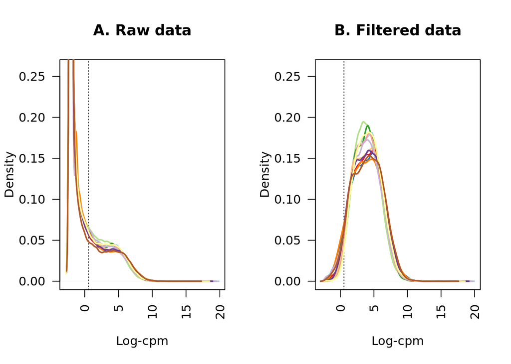

```r
lcpm.cutoff <- log2(10/M + 2/L)
samplenames <- substring(colnames(dge), 12, nchar(colnames(dge)))

## library("RColorBrewer")
nsamples <- ncol(dge)
col <- brewer.pal(nsamples, "Paired")
par(mfrow=c(1,2))
plot(density(lcpm[,1]), col=col[1], lwd=2, ylim=c(0,0.26), las=2, main="", xlab="")
title(main="A. Raw data", xlab="Log-cpm")
abline(v=lcpm.cutoff, lty=3)
for (i in 2:nsamples){
den <- density(lcpm[,i])
lines(den$x, den$y, col=col[i], lwd=2)
}
legend("topright", samplenames, text.col=col, bty="n")

lcpm <- cpm(dge, log=TRUE)
plot(density(lcpm[,1]), col=col[1], lwd=2, ylim=c(0,0.26), las=2, main="", xlab="")
title(main="B. Filtered data", xlab="Log-cpm")
abline(v=lcpm.cutoff, lty=3)
for (i in 2:nsamples){
den <- density(lcpm[,i])
lines(den$x, den$y, col=col[i], lwd=2)
}
legend("topright", samplenames, text.col=col, bty="n")
```

```r
## Niveles medios de expresión
gene_means <- rowMeans(assay(rse_gene_SRP111481, "counts"))
summary(gene_means)
```

```
##      Min.   1st Qu.    Median      Mean   3rd Qu.      Max.
##       0.0       0.0       1.2     131.8      22.0 1966090.7
```

```r
## Eliminar genes no significativos
rse_gene_SRP111481 <- rse_gene_SRP111481[gene_means > 0.1, ]

## Dimensiones finales
dim(rse_gene_SRP111481)
```

```
## [1] 45206    88
```

**Manteniendo el 70.79% de los genes originales.**

```r
## Porcentaje de genes que retuvimos
round(nrow(rse_gene_SRP111481) / nrow(rse_gene_SRP111481_unfiltered) * 100, 2)
```

```
## [1] 70.79
```

# Normalización

La normalización se llevó a cabo desde el filtrado por niveles de expresión. En este apartado mostraré un ejemplo de los efectos de dicha normalización utilizando únicamnete las primeras 10 muestras del objeto `dge`.

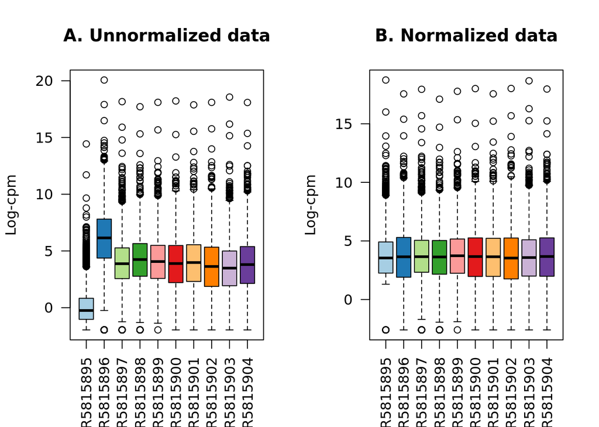

```r
dge_unnorm <- dge[,1:10]
dge_unnorm$samples$norm.factors <- 1
dge_unnorm$counts[,1] <- ceiling(dge_unnorm$counts[,1]*0.05)
dge_unnorm$counts[,2] <- dge_unnorm$counts[,2]*5

par(mfrow=c(1,2))
lcpm <- cpm(dge_unnorm, log=TRUE)
boxplot(lcpm, las=2, col=col, main="")
title(main="A. Unnormalized data",ylab="Log-cpm")
dge_norm <- calcNormFactors(dge_unnorm)

lcpm <- cpm(dge_norm, log=TRUE)
boxplot(lcpm, las=2, col=col, main="")
title(main="B. Normalized data",ylab="Log-cpm")
```

# Visualización

En este punto es necesario visualizar los datos que componen el proyecto para que la parte de modelaje tenga más sentido y las relaciones analizadas sean las adecuadas.

Al tratarse de un estudio de carcinomas tempranos en ovarios, la cantidad de categorías que componen el proyecto son pocas ya que no hay variación en tejido y sexo. Por esta razón las condiciones estudiadas prácticamente se reducen a dos:

1. Edad
2. Etapa FIGO

Recordemos que previamente en la transformación de datos, creamos la categría indicativa `adult` de acuerdo a rangos de edad.

En esta primer gráfica podemos ver la **proporción de genes asignados de acuerdo a a edad y la Etapa FIGO**. A manera general podemos decir que no existe un patrón evidente que relacione algunas de las variables directamente, lo que posiblemente indique que son independientes entre sí.

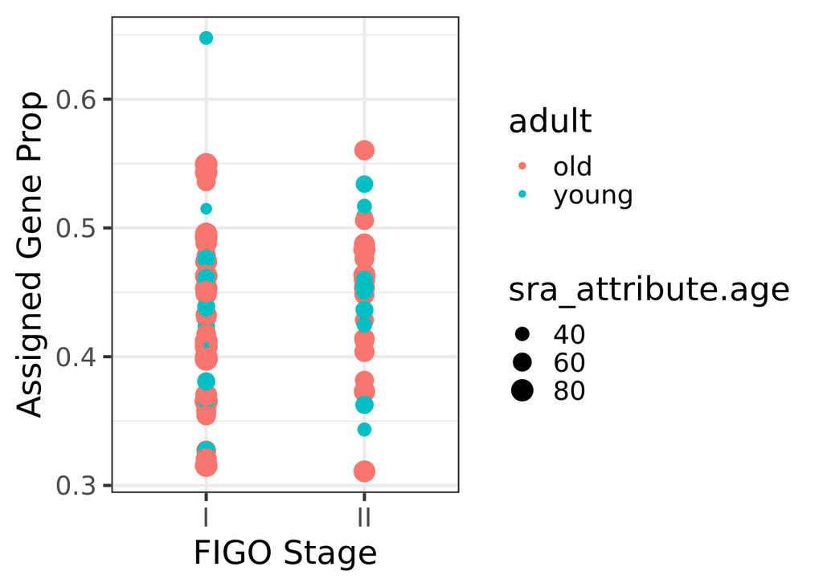

```r
plot_df <- as.data.frame(colData(rse_gene_SRP111481))
ggplot(as.data.frame(colData(rse_gene_SRP111481)), aes(y = assigned_gene_prop, x = sra_attribute.figo_stage)) +
    geom_point(aes(col = adult, size = sra_attribute.age))+
    theme_bw(base_size = 20) +
    ylab("Assigned Gene Prop") +
    xlab("FIGO Stage")
```

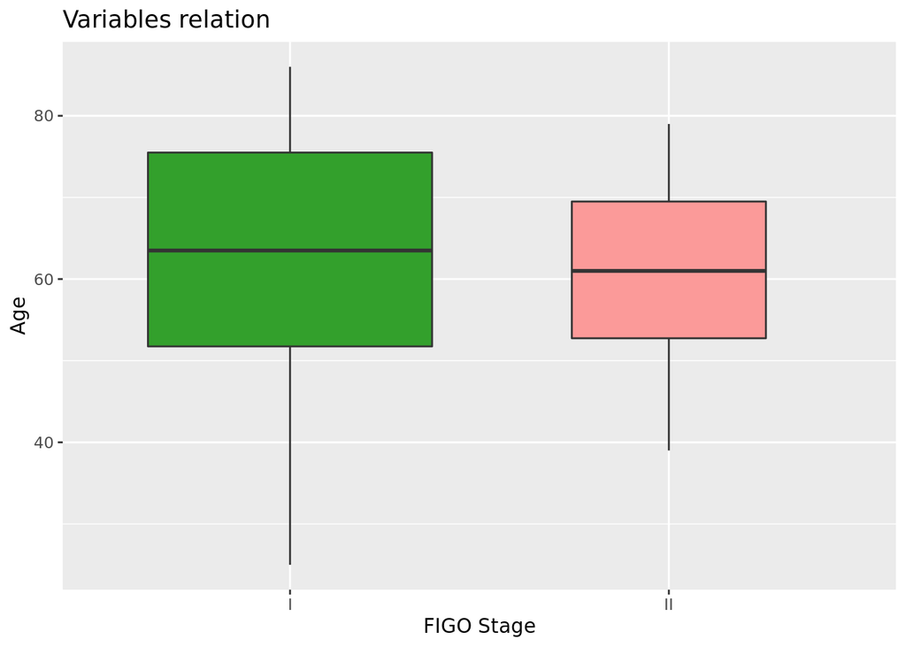

```r
ggplot(plot_df, aes(y = sra_attribute.age, x = sra_attribute.figo_stage)) +
  geom_boxplot(varwidth=T, fill= col[4:5]) +
    labs(title="Variables relation",
         x="FIGO Stage",
         y="Age")
```

# Modelaje

Utilizamos `model.matrix()` para modelar las distintas categorías de nuestro *dataset*, este modelaje nos ayudará a en análisis de expresión diferencial.

```r
mod <- model.matrix(~ sra_attribute.age + adult + sra_attribute.figo_stage + assigned_gene_prop,
    data = colData(rse_gene_SRP111481)
)
colnames(mod)
```

```
## [1] "(Intercept)"                "sra_attribute.age"
## [3] "adultyoung"                 "sra_attribute.figo_stageII"
## [5] "assigned_gene_prop"
```

Antes del ajuste de datos necesitamos saber qué tan desviados están, así el ajuste será el adecuado.

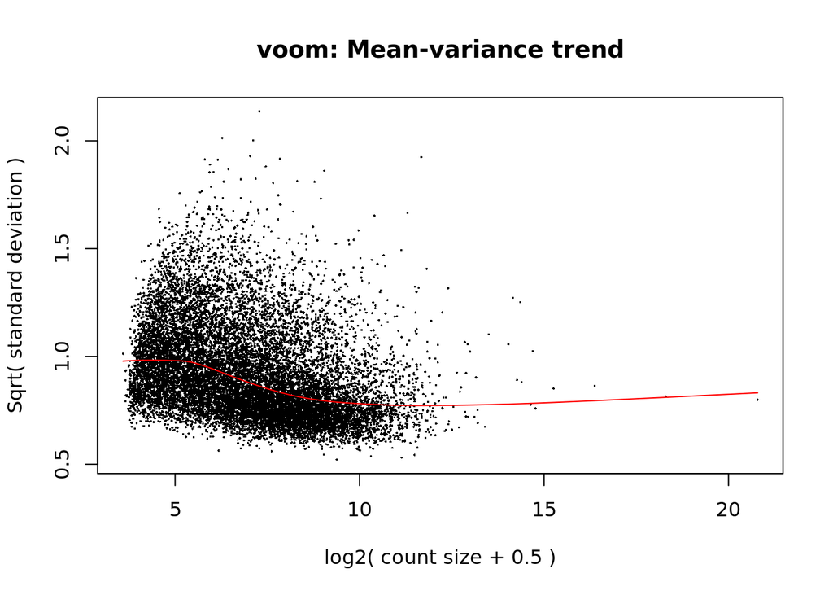

```r
## library("limma")
vGene <- voom(dge, mod, plot = TRUE)
```

Ajuste de datos y evaluación respecto a la categoría `figo_stage` (`coef = 4`).

```r
## Ajuste de datos
eb_results <- eBayes(lmFit(vGene))

## Rank de datos
de_results <- topTable(
    eb_results,
    coef = 4,
    number = nrow(rse_gene_SRP111481),
    sort.by = "none"
)
dim(de_results)
```

```
## [1] 14984    16
```

Además de que no hay una formación de conos fuerte, probablemente esto se deba a la limpieza de genes con bajos niveles de expresión.

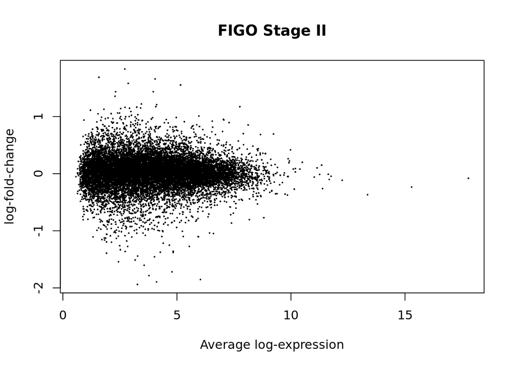

```r
## Visualicemos los resultados estadísticos
plotMA(eb_results, coef = 4, main = "FIGO Stage II")
```

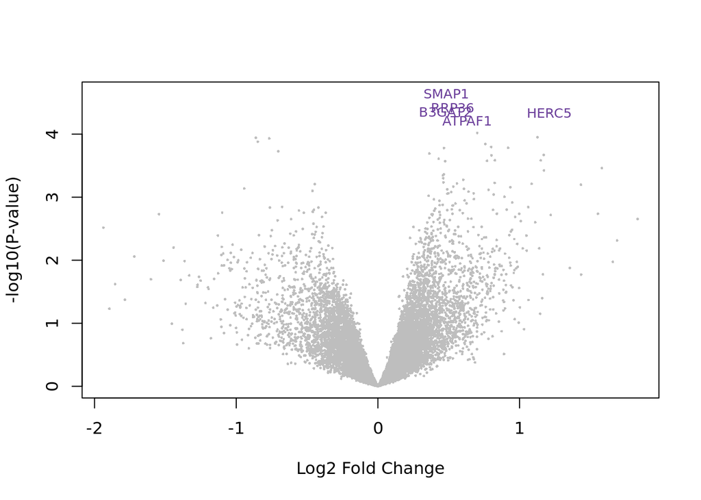

```r
volcanoplot(eb_results, coef = 4, highlight = 5, names = de_results$gene_name, col="grey", hl.col = col[10])
```

De igual manera es importante destacar que aparentemente no existe una relación estrecha entre expresión diferencial y edad.

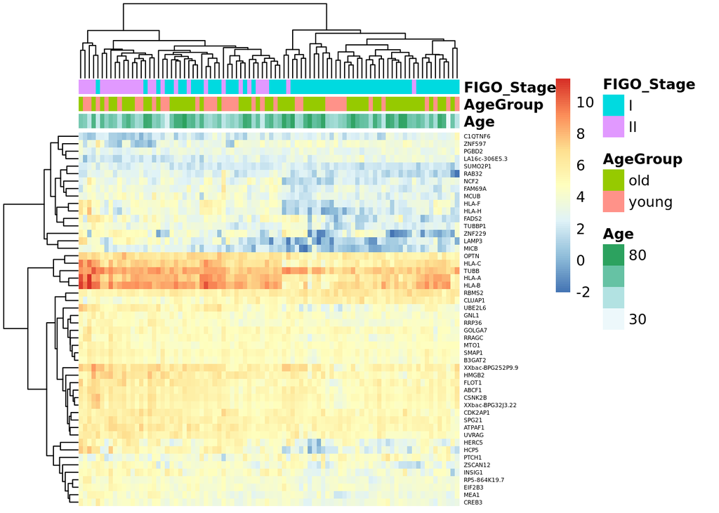

```r
## Extraer valores de los genes de interés
exprs_heatmap <- vGene$E[rank(de_results$adj.P.Val) <= 50, ]

## Creemos una tabla con información de las muestras
## y con nombres de columnas más amigables
df <- as.data.frame(colData(rse_gene_SRP111481)[, c("sra_attribute.age", "adult", "sra_attribute.figo_stage")])
colnames(df) <- c("Age", "AgeGroup", "FIGO_Stage")

## Hagamos un heatmap
library("pheatmap")
# Obtener los nombres a partir de los IDs en el arreglo general
namesIndex <- match(rownames(exprs_heatmap), de_results$gene_id)
geneNames <- de_results$gene_name[namesIndex]
# Modificar los nombres del heatmap
row.names(exprs_heatmap) <- geneNames

pheatmap(
    exprs_heatmap,
    cluster_rows = TRUE,
    cluster_cols = TRUE,
    show_rownames = TRUE,
    show_colnames = FALSE,
    annotation_col = df,
    fontsize_row = 4
)
```

# Conclusiones

A lo largo del proyecto se manipularon datos crudos desde la **obtención, limpieza, transformación, visualización y modelaje**; a través de cada una de las etapas se buscó mejorar la calidad de la información generada a partir de la manipulación de los mismos datos. Considero que cada etapa del proceso de análisis de datos de expresión diferencial es importante, la sucesión de estas etapas resulta en la obtención de información puntual de un océano de datos.

En cuestiones de código, las bibliotecas de análisis de expresión diferencial utilizadas me parecieron muy amigables debido a la facilidad de búsqueda de información y contenido. Las funciones son claras y vienen bien documentadas. Particularmente me impresionó la capacidad de `limma`, pensé que al se un paquete no tan reciente tendría muchas limitantes de compatibilidad de objetos y manipulación de funciones. Sin embargo, el único detalle que encontré fue que la construcción de gráficas no es muy libre en cuanto a formato (colores, divisiones, etc.).

Este fue el primer acercamiento que tuve a manejo de datos de expresión diferencial, estoy segura de que queda mucho por pulir y aprender, sin embargo estoy muy contenta con el resultado de este proyecto y las habilidades que me permitió desarrollar. Seguiré estudiando y trabajando en el tema, las aplicaciones son impresionantes y me gustaría seguir aprendiendo de lo mucho que pueda lograr a partir de la manipulación de datos de expresión.